# Pacific herring (Clupea pallasii) as a key forage fish in the southeastern Gulf of Alaska - ScienceDirect

## [Deep Sea Research Part II: Topical Studies in Oceanography](https://www-sciencedirect-com.reed.idm.oclc.org/journal/deep-sea-research-part-ii-topical-studies-in-oceanography)

[Volume 196](https://www-sciencedirect-com.reed.idm.oclc.org/journal/deep-sea-research-part-ii-topical-studies-in-oceanography/vol/196/suppl/C), February 2022, 105001

# Pacific herring (*Clupea pallasii*) as a key forage fish in the southeastern Gulf of Alaska

https://doi.org/10.1016/j.dsr2.2021.105001[Get rights and content](https://s100.copyright.com/AppDispatchServlet?publisherName=ELS&contentID=S0967064521000771&orderBeanReset=true)

## Highlights

- •

  Pacific herring is an important forage fish in the southeastern Gulf of Alaska.
- •

  The high energy content of herring enhances its importance as a forage fish.
- •

  Depleting herring stocks risks notable impacts on their predators and prey.

## Abstract

Pacific herring (*Clupea pallasii*) is a schooling planktivorous fish consumed by numerous fish, seabirds, and [marine mammals](https://www-sciencedirect-com.reed.idm.oclc.org/topics/earth-and-planetary-sciences/marine-mammal). This paper aimed to determine whether Pacific herring serves as a key forage fish (i.e. strongly supports predator populations) in the southeastern Gulf of Alaska. All analyses were conducted using mass- and energy-balanced ecosystem models constructed in Ecopath with Ecosim. Supportive Role to Fishery (*SURF*) index values were computed using predator diets and food web structure encoded in static ecosystem models. Ecosystem impacts of herring stock depletion and collapse were evaluated using quantitative criteria (thresholds) applied to dynamic ecosystem simulations. *SURF* index values from mass-balanced models lay below the threshold required to designate herring as a key forage fish. However, values from an energy-balanced model supported the key status of herring. Dynamic ecosystem simulations in mass- and energy-balanced models revealed strong negative effects of herring depletion on several predators. In most energy-balanced models, simulation results designated herring as a key forage fish despite indications of functional redundancy in the forage fish guild. Impacts of herring depletion on predators were stronger and more numerous in energy-balanced models, suggesting that the high energy content of herring enhances its importance to predators. Simulation results also demonstrated positive impacts of herring depletion on two zooplankton groups due to release from predation pressure. The status of Pacific herring as a key forage fish apparently depends on its energy content relative to other forage fish. Nevertheless, the results of this study support precautionary, ecosystem-based management of Pacific herring fisheries.

- [Previous article in issue](https://www-sciencedirect-com.reed.idm.oclc.org/science/article/pii/S096706452200008X)

## Keywords

Marine ecology

Trophic relationships

Clupeoid fisheries

Forage species

Forage fish

Herring

Pacific herring

*Clupea pallasii*

Ecosystem modelling

Ecopath with Ecosim

Mass balance

Energy balance

Pacific Ocean

Northeast Pacific

Gulf of Alaska

## 1. Introduction

Forage fish (i.e. small, schooling planktivores) form narrow trophic conduits channeling energy from zooplankton to higher predators, including diverse piscivorous fish, seabirds, and [marine mammals](https://www-sciencedirect-com.reed.idm.oclc.org/topics/agricultural-and-biological-sciences/marine-mammal) (Cury et al., 2011, Smith et al., 2011, Pikitch et al., 2012a,b; Engelhard et al., 2014). The unique importance of forage fish to these predators is likely reinforced (Litzow et al. 2004, 2006; Spitz et al. 2010a, 2012, 2018) by the elevated energy content of forage fish relative to most other fish and invertebrates (Perez 1994; Anthony et al., 2000; Vollenweider et al., 2011; Spitz et al., 2010b; Spitz and Jouma'a 2013). Furthermore, numerous industrial, artisanal, aboriginal, and subsistence fisheries target forage or piscivorous fish, thereby relying, directly or indirectly, on forage fish productivity (Pikitch et al., 2012a,b, Engelhard et al., 2014). Thus, metrics derived from static ecosystem models and food web structure (Plagányi and Essington 2014) as well as from dynamic ecosystem simulations (Smith et al., 2011) have been devised to identify key forage fish, i.e. species providing particularly strong support for predators and fisheries.

The main aim of this paper is to determine whether Pacific herring (*Clupea pallasii*) functions as a key forage fish in the southeastern Gulf of Alaska ecosystem. In a global analysis investigating the importance of forage fish to predators (and thus to fisheries targeting them) using the novel SUpportive Role to Fisheries (*SURF*) index based on static food web structure and validated with dynamic ecosystem simulation, 27 forage stocks belonging to five families (Clupeidae, [Engraulidae](https://www-sciencedirect-com.reed.idm.oclc.org/topics/agricultural-and-biological-sciences/engraulidae), [Osmeridae](https://www-sciencedirect-com.reed.idm.oclc.org/topics/agricultural-and-biological-sciences/osmeridae), [Ammodytidae](https://www-sciencedirect-com.reed.idm.oclc.org/topics/agricultural-and-biological-sciences/ammodytidae), and Scombridae) were identified as key in 17 ecosystems worldwide (Plagányi and Essington 2014). These stocks included Pacific herring in Prince William Sound but not the west-central Gulf of Alaska, Hecate Strait, or Puget Sound.

Some forage fish, particularly in upwelling ecosystems, have been suggested to exhibit “wasp-waist” dynamics, i.e. simultaneously exert top-down control on prey and bottom-up control on predators (Cury et al., 2000). However, the high degree of omnivory displayed by numerous marine predators (Madigan et al., 2012) and the apparent redundancy in the forage fish guilds of many ecosystems (Bundy and Guénette 2014) have cast doubt on this hypothesis. Nevertheless, forage fish apparently exert top-down control on zooplankton in some cases (Cury et al., 2000) and are controlled by them in a bottom-up fashion in others (Engelhard et al., 2014). Relatively strong evidence exists of forage fish exercising bottom-up control over numerous predators, particularly central place foragers and mobile species forming large feeding aggregations (Smith et al., 2011, Pikitch et al., 2012a,b; Engelhard et al., 2014). These groups include most seabirds (Cury et al., 2011; Hannesson 2013; Sydeman et al., 2017a), numerous [marine mammals](https://www-sciencedirect-com.reed.idm.oclc.org/topics/earth-and-planetary-sciences/marine-mammal) (e.g. McClatchie et al., 2016a, Marçalo et al., 2018, Giralt et al., 2021, Tsagarakis et al., 2021), and piscivorous fish (e.g. Kaplan et al., 2017; Koehn et al., 2017). Thus, exploiting forage fish may impair the trophic support they provide to charismatic and fished predators (Pikitch et al., 2012a,b; Smith et al., 2011), especially for key forage fish (Plagányi and Essington 2014), although this effect may be reversed by high predator [fishing mortality](https://www-sciencedirect-com.reed.idm.oclc.org/topics/earth-and-planetary-sciences/fish-mortality) (Soudijn et al., 2021). Prey switching by predators exhibiting the sigmoid Type III functional response (Holling 1959), along with the functional redundancy characterizing forage fish guilds in many ecosystems (Bundy and Guénette 2014), may buffer the adverse impacts of exploiting forage fish on predator populations (Hilborn et al., 2017; Free et al., 2021). However, simple predator-prey models suggest that these buffering mechanisms may fail due to recruitment limitation in both forage and piscivorous fish, allowing efficient [piscivores](https://www-sciencedirect-com.reed.idm.oclc.org/topics/earth-and-planetary-sciences/piscivore) to inflict depensatory mortality on exploited forage fish (Walters et al., 2016).

Forage fish are also characterized by an r-selected life history including high fecundity and natural mortality, short lifespan, and early maturation (Pikitch et al., 2012b). These traits, combined with the close link between forage fish stock status and bottom-up oceanographic drivers, produce high-amplitude fluctuations in forage fish biomasses on interannual to multidecadal scales (McClatchie et al., 2017; Trochta et al., 2020). Such fluctuations, which may be intensified by depensatory predation mortality (Walters et al., 2016; Jacobsen and Essington 2018), render forage fish particularly susceptible to stock collapses (McClatchie et al., 2017; Trochta et al., 2020), especially when [stock assessment](https://www-sciencedirect-com.reed.idm.oclc.org/topics/earth-and-planetary-sciences/stock-assessment) models overestimate biomass in less productive years, resulting in ineffective management and excessive fishing mortality (Pinsky and Byler 2015; Essington et al., 2015). Furthermore, due to their [schooling behaviour](https://www-sciencedirect-com.reed.idm.oclc.org/topics/earth-and-planetary-sciences/schooling-behavior), forage fish are prone to depensatory increases in catchability, which also promote stock collapses (Pitcher 1995). This vulnerability of forage fish to exploitation, combined with their apparent importance to numerous fished, protected, and charismatic predators (Smith et al., 2011, Pikitch et al., 2012a,b; Engelhard et al., 2014), has stimulated global calls for precautionary, ecosystem-based management of these prey species (Stephenson 1997, Smith et al., 2011, Pikitch et al., 2012a,b) and lends particular importance to the identification of key forage fish. However, several recent studies question the importance of forage fish to predators and thus the need for changes to existing fisheries management practices (Hilborn et al., 2017; Free et al., 2021).

Pacific herring is a large, long-lived forage fish inhabiting the coastal North Pacific from the Yellow Sea to the California Current (Hay et al., 2008). Off the central coast of British Columbia (Canada), it preys on diverse zooplankton including copepods, pelagic [amphipods](https://www-sciencedirect-com.reed.idm.oclc.org/topics/agricultural-and-biological-sciences/amphipoda), [euphausiids](https://www-sciencedirect-com.reed.idm.oclc.org/topics/agricultural-and-biological-sciences/krill), pteropods, and ichthyoplankton (Pakhomov et al., 2017). In the Northeast Pacific, including the Gulf of Alaska, herring is an important prey species for numerous commercial fish (Brodeur et al., 2014; Osgood et al., 2016; Chamberlin et al., 2021) and seabirds (Schrimpf et al., 2012; Bishop et al., 2015; Sydeman et al., 2017b; Drever et al., 2021) as well as many marine mammals, including humpback whales (*[Megaptera novaeangliae](https://www-sciencedirect-com.reed.idm.oclc.org/topics/agricultural-and-biological-sciences/megaptera-novaeangliae)*; Boswell et al., 2015, Moran et al., 2018; Straley et al., 2018) and [Steller sea lions](https://www-sciencedirect-com.reed.idm.oclc.org/topics/agricultural-and-biological-sciences/steller-sea-lion) (*Eumetopias jubatus*; Gende and Sigler 2006; Womble and Sigler 2006; Sigler et al., 2017). Most of these marine mammals and seabirds are protected under the United States [Endangered Species](https://www-sciencedirect-com.reed.idm.oclc.org/topics/agricultural-and-biological-sciences/endangered-species) Act, Migratory Bird Treaty Act, or Marine Mammal Protection Act.

Due to its importance to these predators, Schweigert et al. (2010) consider herring the principal forage fish in British Columbia waters, while Fox et al. (2015, 2018) identify it as a foundation species. Like [keystone species](https://www-sciencedirect-com.reed.idm.oclc.org/topics/agricultural-and-biological-sciences/keystone-species), foundation species interact strongly within the food web, but unlike [keystone species](https://www-sciencedirect-com.reed.idm.oclc.org/topics/earth-and-planetary-sciences/keystone-species), they are often highly abundant (Soulé et al., 2003). Pacific herring is also an important forage fish in the California Current (Szoboszlai et al., 2015) as far south as San Francisco Bay (Thayer et al., 2020). The forage role of Pacific herring is especially strong and taxonomically extensive during the spring spawning season, when both fish and roe sustain a diverse coastal predator guild (Willson and Womble 2006; Lok et al., 2012, Thayer et al., 2020). Furthermore, its high energy content relative to most other forage and non-forage fish as well as invertebrates in the Gulf of Alaska (Perez 1994; Anthony et al., 2000; Vollenweider et al., 2011) likely renders herring an especially desirable prey species. The only coastal Northeast Pacific forage fish consistently exceeding herring in energy content is eulachon (*Thaleichthys pacificus*), an anadromous smelt formerly abundant and important as salmon prey but now much less abundant than herring (Osgood et al., 2016). This suggests that numerous predators in the southeastern Gulf of Alaska may rely on herring for substantial fractions of their energetic demands (Surma et al., 2018a). Thus, Pacific herring is a potentially key forage fish.

However, the directions and magnitudes of [trophic interactions](https://www-sciencedirect-com.reed.idm.oclc.org/topics/earth-and-planetary-sciences/trophic-interaction) between Pacific herring and its predators have only recently begun to be studied in depth. Schweigert (1997) detected minor but significant improvements in Ricker stock-recruitment model fits to data for northern British Columbia stocks of Pacific cod (*Gadus macrocephalus*), [chinook salmon](https://www-sciencedirect-com.reed.idm.oclc.org/topics/agricultural-and-biological-sciences/oncorhynchus-tshawytscha) (*[Oncorhynchus](https://www-sciencedirect-com.reed.idm.oclc.org/topics/agricultural-and-biological-sciences/oncorhynchus)* *tshawytscha*), and rock sole (*Lepidopsetta bilineata*) upon including herring abundance as a predictor, with the weak impacts on these predators likely due to functional redundancy in the forage fish guild. In the Gulf of Alaska, the latter also includes Pacific sandlance (*[Ammodytes](https://www-sciencedirect-com.reed.idm.oclc.org/topics/agricultural-and-biological-sciences/ammodytes)* *personatus*) and various smelts (Osmeridae), notably Pacific capelin (*Mallotus catervarius*). Schweigert et al. (2010) observed a paradoxical negative correlation between consumption by predators and total natural mortality in herring off the west coast of Vancouver Island, perhaps indicating density-dependent effects. Mounting evidence suggests that recovering humpback whales may exert top-down control over Northeast Pacific herring (Ford et al., 2009; Heintz et al., 2010; Surma and Pitcher 2015; Boswell et al., 2015; Moran et al., 2018; Straley et al., 2018). A recent ecosystem modelling study (Surma et al., 2019) detected multiple strong interactions of both signs between herring and its predators and prey in the southeastern Gulf of Alaska.

Numerous commercial, aboriginal, and subsistence fisheries in the Gulf of Alaska exploit Pacific herring directly or rely on it to support piscivorous fish stocks (Pikitch et al., 2012a,b), including lingcod (*[Ophiodon elongatus](https://www-sciencedirect-com.reed.idm.oclc.org/topics/agricultural-and-biological-sciences/ophiodon-elongatus)*), Pacific salmon (*Oncorhynchus* spp*.*) and rockfish (*[Sebastes](https://www-sciencedirect-com.reed.idm.oclc.org/topics/agricultural-and-biological-sciences/sebastes)* spp*.*). Zooarchaeological data reveal that local aboriginal peoples have depended on abundant herring (McKechnie et al., 2014, Moss et al., 2016) and piscivorous fishes (McKechnie and Moss 2016) for millennia prior to first contact. Herring continues to play important subsistence and cultural roles for the Heiltsuk (Gauvreau et al., 2017), Gitxaaƚa (Menzies 2016, ch. 6), Haida (Jones et al., 2017), and Tlingit (Thornton et al., 2010; Moss et al., 2011).

However, in recent years, the depressed status of many Pacific herring stocks from Alaska to California has raised increasing concern among scientists (Cleary et al., 2010; Schweigert et al., 2010; Pearson et al., 2012; Thompson et al., 2017), management agencies (NMFS 2014; DFO 2015; Kronlund et al., 2018), and aboriginal peoples (Thornton et al., 2010; Jones et al., 2017; Gauvreau et al., 2017). It has also stimulated the latter to advocate for increased precaution and transparency in herring fisheries management, despite repeated assertions in analyses conducted by management agencies (Haist et al. 1986, 1993; Hall et al., 1988; Zheng et al., 1993; Funk and Rowell 1995; Cleary et al., 2010) that the status quo is precautionary enough, at least from a single-species perspective. Neither bottom-up nor top-down control alone has conclusively explained the depression of these stocks, although both of these mechanisms are likely involved along with non-trophic factors (Schweigert et al., 2010; Pearson et al., 2012; NMFS 2014). For example, in Prince William Sound, [freshwater runoff](https://www-sciencedirect-com.reed.idm.oclc.org/topics/earth-and-planetary-sciences/freshwater-runoff) and density-dependence (Ward et al., 2017), pathogens (Marty et al., 2003), the 1989 *Exxon Valdez* oil spill (Thorne and Thomas 2008; Incardona et al., 2015), and increased predation by recovering humpback whales (Moran et al., 2018; Straley et al., 2018) may all have been contributing factors. In any case, the importance of herring to aboriginal and [commercial fisheries](https://www-sciencedirect-com.reed.idm.oclc.org/topics/earth-and-planetary-sciences/commercial-fishery) and the depression of many stocks in the Gulf of Alaska underscore the acute need for improved knowledge of the trophic interactions linking this potentially key forage fish to its numerous predators. Identification of Pacific herring as a key forage fish would support precautionary, ecosystem-based, and ethical management of Northeast Pacific herring fisheries (Surma et al., 2018b; Lam et al., 2019).

## 2. Materials and methods

### 2.1. Ecosystem models

This study utilized two previously published (Surma et al., 2019) mass-balanced models built in Ecopath with Ecosim (EwE; Christensen and Walters, 2004), one of the most commonly used ecosystem modelling frameworks (Coll et al., 2015). These models represented the southeastern Gulf of Alaska ecosystem states existing in historical (1950) and recent (2000–2015) periods, respectively. The models were designed to quantify the trophic role of herring during the period a) of high finfish and low [marine mammal](https://www-sciencedirect-com.reed.idm.oclc.org/topics/agricultural-and-biological-sciences/marine-mammal) abundance in the mid-20th century and b) following the finfish declines and [marine mammal](https://www-sciencedirect-com.reed.idm.oclc.org/topics/earth-and-planetary-sciences/marine-mammal) recoveries of the late 20th century (Surma et al., 2019).

This study also employed seven energy-balanced EwE models representing the recent state of the southeastern Gulf of Alaska ecosystem. These models were designed to account for the enhanced importance of herring to numerous predators (Surma et al., 2018a) due to its high energy content relative to most other prey (Perez 1994; Anthony et al., 2000; Vollenweider et al., 2011). Each energy-balanced model was constructed using the recently developed method of rescaling basic mass-balanced Ecopath model parameters (biomass, t⋅km<sup>−2</sup>; consumption per biomass, yr<sup>−1</sup>; and diet composition) with published energy content values (kJ⋅g<sup>−1</sup> wet weight; Appendix B, Table B1) for all functional groups. The first two models employed the highest and lowest published energy content values for each group, respectively, while the remaining five were derived from energy content values randomly resampled from uniform distributions bounded by the highest and lowest values (Appendix B, Table B2). The fundamental principles of EwE and the energy-balanced modelling method (Surma et al., 2018a) are summarized in Appendix A, while basic parameters for all energy-balanced models are provided in Appendix B (Tables B3-B9).

The recent mass-balanced model was selected as the basis for all energy-balanced models to avoid the assumption that recent energy content values (Perez 1994; Anthony et al., 2000; Vollenweider et al., 2011) are applicable to the historical model. This assumption is put into question by documented density-dependent declines (e.g. Casini et al., 2006) and oceanographically driven fluctuations (e.g. Siddon et al., 2013; Suryan et al., 2021) in forage fish energy content. The decision to base the energy-balanced models on the recent mass-balanced model required the likewise questionable assumption that vulnerability parameter values obtained from fitting the historical mass-balanced model to time series may be utilized in models representing the recent ecosystem state (Ainsworth et al., 2008). For the purpose of comparisons between mass- and energy-balanced models, however, the impacts of this assumption on the credibility of Ecosim outputs are mitigated by the fact that identical vulnerabilities were employed in the mass- and energy-balanced models.

### 2.2. Static ecosystem analyses

Due to its detailed qualitative and quantitative representation of static food web structure, the SUpportive Role to Fishery (*SURF*) index (Plagányi and Essington 2014) was employed as the first metric assessing the support provided to predators by herring, and hence its importance as a forage fish, in the southeastern Gulf of Alaska. According to Plagányi and Essington (2014):$SURF=∑j=1Spij2L$where *S* is the number of predators *j* in the food web, *p*<sub>*ij*</sub> is the fraction of prey *i* in the diet of predator *j*, and *L* is the number of links in the food web. Thus, unlike connectance (i.e. the number of trophic links to a forage fish/ total number of food web links), utilized by an earlier study (Smith et al., 2011) to assess forage fish importance to predators, *SURF* quantitatively evaluates predator dependence on forage fish (Plagányi and Essington 2014). Furthermore, *SURF* is less sensitive than connectance to the common ecosystem modelling practice of aggregating multiple predators into single functional groups (Plagányi and Essington 2014). Based on a comparison of *SURF* scores with metrics derived from dynamic simulations using multiple EwE models, *SURF* = 0.001 was adopted as the approximate threshold for key forage fish status (Plagányi and Essington 2014).

Herring *SURF* was calculated and compared across all mass-balanced and energy-balanced EwE models of the southeastern Gulf of Alaska ecosystem. In these calculations, all four local herring stocks (Haida Gwaii, Haida Gwaii 2 West, Prince Rupert District, and Central Coast) and all three age/size classes (age 0, age 1–2, and age 3+) represented in the models were considered together. Thus, overall herring *p*<sub>*ij*</sub> was calculated as $∑k=1npkj$, where *n* = 12 is the number of herring groups *k* in the models, while in calculating *L* all links between the *n* herring groups and each prey *i* or predator *j* were counted as single links. *SURF* was also computed and compared across all models for the three other forage fish functional groups, i.e. forage fish (primarily sandlance and smelts, including capelin), Pacific saury *[Cololabis saira](https://www-sciencedirect-com.reed.idm.oclc.org/topics/agricultural-and-biological-sciences/cololabis-saira)*, and eulachon.

### 2.3. Dynamic ecosystem simulations

Impacts of simulated herring depletion on predators provided the second metric of the forage role of herring in the southeastern Gulf of Alaska. For herring to be classified as a key forage fish (Plagányi and Essington 2014) based on simulation results, the impacts of 60% herring depletion (i.e. reduction to 40% of unfished biomass), would have to include A1) a decline ≥70% in at least one functional group or B) declines of 40–69% in at least 10% of predators (i.e. groups with [trophic level](https://www-sciencedirect-com.reed.idm.oclc.org/topics/agricultural-and-biological-sciences/trophic-level) ≥3). The weaker criterion A2, derived from an earlier study (Smith et al., 2011), employed a slightly lower threshold than A1 (a decline ≥60% in at least one group).

Simulation methods were based on those employed in a pilot study (Surma et al., 2018b) but utilized improved food web models with increased functional group resolution for seabirds, invertebrates (zooplankton and benthos), and benthic producers, as well as a new fit to time series (Surma et al., 2019). As in the pilot study, all Ecosim runs lasted 100 simulated years and a scenario (#1) representing herring fisheries closure (*F* = 0) served as a baseline. Unlike in the pilot study, however, another Ecosim scenario (#2) simulating 60% depletion of adult herring (ages 3+) was run to yield simulation metrics of key forage fish status (Smith et al., 2011; Plagányi and Essington 2014). As in the pilot study, the final scenario (#3) represented herring stock collapse (i.e. 95% depletion). All three Ecosim scenarios were evaluated across all mass- and energy-balanced models. Unlike in the pilot study, in scenarios #2 and #3 [fishing mortality](https://www-sciencedirect-com.reed.idm.oclc.org/topics/earth-and-planetary-sciences/fish-mortality) was only increased for adult herring. The reasons for this were twofold. Firstly, recent catches of juvenile herring (age 1–3) in the southeastern Gulf of Alaska were negligible (as the roe fishery dominant since the early 1970s exclusively targets pre-spawners). Secondly, the models suggest that adult herring were most heavily consumed by predators. A substantial majority of spawning herring in the study area have, until very recently, been age 3+ (Schweigert et al., 2010). Fishing mortalities for all other functional groups remained at baseline levels (Surma et al., 2019) across all scenarios.

In order to generate realistic trends in potential ecosystem change and account for impacts of top-down and bottom-up forcing simultaneous with herring depletion, two sets of time series were employed in all scenarios, as in the pilot study (Surma et al., 2018b). Firstly, time series representing reconstructed and projected biomass trajectories of five historically depleted whale species (i.e. humpback, blue *[Balaenoptera musculus](https://www-sciencedirect-com.reed.idm.oclc.org/topics/agricultural-and-biological-sciences/balaenoptera-musculus)*, fin *B. physalus*, sei *B. borealis*, and sperm *[Physeter macrocephalus](https://www-sciencedirect-com.reed.idm.oclc.org/topics/agricultural-and-biological-sciences/physeter-macrocephalus)*) were utilized to simulate whale population recoveries and evaluate their ecosystem impacts across all mass- and energy-balanced models. Previous simulations indicate these effects may be substantial in the southeastern Gulf of Alaska (Surma and Pitcher, 2015), suggesting the need to include them in other ecosystem simulations. Whale abundance reconstructions and projections were derived from surplus production models (Surma 2019) based on historical whaling catches (Nichol and Heise 1992), recent abundance estimates, and annual population rates of increase for each species, following the basic approach described in Surma and Pitcher (2015). Abundances were converted to biomasses using species-specific average individual masses (Trites and Pauly 1998). Whale biomass time series drivers were deactivated in one of two Ecosim runs for each scenario to evaluate possible bottom-up impacts of herring availability on whale populations. For energy-balanced models, whale biomass (t⋅km<sup>−2</sup>) time series were converted to energy (J⋅m<sup>−2</sup>) using the energy content (kJ⋅g<sup>−1</sup>) values provided in Appendix B, (Table B1). Otherwise, all Ecosim scenarios were run identically across the recent mass- and energy-balanced models.

Secondly, in the historical model, bottom-up effects of stochastic interannual variability in primary productivity were represented in Ecosim by a phytoplankton biomass time series. The 1950–2015 time series utilized to fit the model and generate hindcasts (Surma et al., 2019) was extended by 100 years through randomized resampling with repetition from a phytoplankton biomass dataset for 1950–2000 (Ainsworth et al., 2008). All whale and phytoplankton time series employed in this study are provided in supplementary file S1. In the historical model, in order to correctly represent fisheries and ecosystem dynamics up to and including the scenario start time, historical fishing mortality trends were imposed on all exploited functional groups until 2015 (Surma et al., 2019), whereupon the baseline, depletion, and collapse simulations (i.e. scenarios #1-3) were initialized.

## 3. Results

### 3.1. Static ecosystem analyses

Herring *SURF* index values for each model appear in Fig. 1. In the mass-balanced models (historical and recent), herring *SURF* did not exceed 0.001, the key forage fish status threshold (Plagányi and Essington 2014). In five out of seven energy-balanced models (#1, #2, #4, #6, and #7), herring *SURF* surpassed 0.0005 but lay below the key status threshold. However, in one energy-balanced model (#3), herring *SURF* exceeded 0.001, thus narrowly meeting the key forage fish status requirement. For the forage fish group, *SURF* surpassed the key status threshold in all models. For saury and eulachon, *SURF* lay below 0.001 across all models.

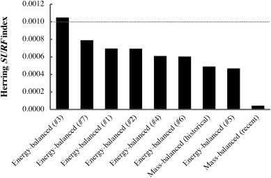

1. [Download: Download high-res image (182KB)](https://ars-els-cdn-com.reed.idm.oclc.org/content/image/1-s2.0-S0967064521000771-gr1_lrg.jpg)
2. [Download: Download full-size image](https://ars-els-cdn-com.reed.idm.oclc.org/content/image/1-s2.0-S0967064521000771-gr1.jpg)

Fig. 1. Herring *SURF* index values computed from nine models of the southeastern Gulf of Alaska ecosystem. The dotted line marks the key forage fish status threshold (*SURF* = 0.001) according to Plagányi and Essington (2014).

### 3.2. Dynamic ecosystem simulations

Simulation results (Fig. 2, Fig. 3, Fig. 4) revealed notable differences in key forage fish status metrics for herring between scenario #2 (depletion) and scenario #3 (collapse), as well as between recent mass- and energy-balanced models. Key forage status criterion A1 (at least one functional group decline ≥70%; Plagányi and Essington 2014) was satisfied in scenario #3 (collapse) but not in scenario #2 (depletion) by both mass-balanced models (historical and recent), as well as three energy-balanced models (#4–6). However, the threshold for criterion A1 was attained in both scenarios by the remaining four energy-balanced models, yielding majority support for herring key status among energy-balanced models. With model #3 (which employed extremely high herring energy content values) excluded, half of the energy-balanced models classified herring as key under criterion A1. The weaker key status criterion A2 (at least one group decline ≥60%; Smith et al., 2011) was satisfied in scenario #3 (collapse) but not in scenario #2 (depletion) by both mass-balanced models, although it was very nearly met by the recent model in scenario #2 (Fig. 3). However, the threshold for criterion A2 was exceeded in both scenarios by all energy-balanced models (Fig. 3, Fig. 4). Key forage status criterion B (40–69% declines in ≥10% of predators; Plagányi and Essington 2014) was not satisfied by any model in either scenario, despite at least one predator decline of 40–69% occurring in all models and scenarios except the historical mass-balanced model in scenario #2 (Fig. 2, Fig. 3, Fig. 4).

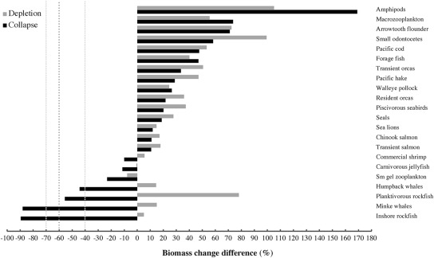

1. [Download: Download high-res image (287KB)](https://ars-els-cdn-com.reed.idm.oclc.org/content/image/1-s2.0-S0967064521000771-gr2_lrg.jpg)
2. [Download: Download full-size image](https://ars-els-cdn-com.reed.idm.oclc.org/content/image/1-s2.0-S0967064521000771-gr2.jpg)

Fig. 2. Results of the herring depletion (60% biomass reduction, grey) and collapse (95% biomass reduction, black) simulations in the historical mass-balanced model, expressed as percentage differences between final functional group biomasses in the depletion and collapse scenarios versus the baseline (herring *F* = 0) scenario. Lg dem sharks = large demersal sharks and sm gel zooplankton = small [gelatinous zooplankton](https://www-sciencedirect-com.reed.idm.oclc.org/topics/agricultural-and-biological-sciences/gelatinous-zooplankton). The dotted lines mark the thresholds employed to assess key forage fish status.

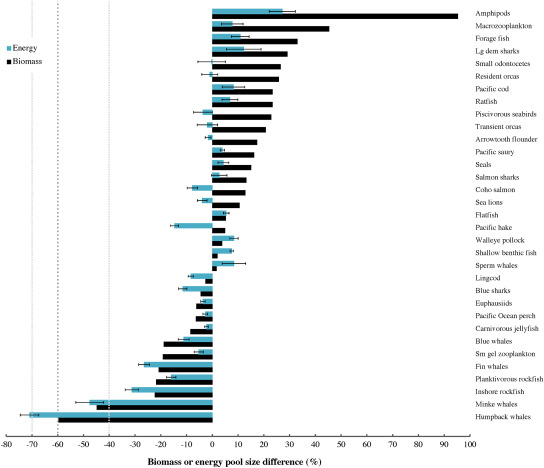

1. [Download: Download high-res image (400KB)](https://ars-els-cdn-com.reed.idm.oclc.org/content/image/1-s2.0-S0967064521000771-gr3_lrg.jpg)
2. [Download: Download full-size image](https://ars-els-cdn-com.reed.idm.oclc.org/content/image/1-s2.0-S0967064521000771-gr3.jpg)

Fig. 3. Results of the herring depletion simulation in the recent mass- and energy-balanced models, expressed as percentage differences (≥10%) between final functional group biomasses (black) and [energy densities](https://www-sciencedirect-com.reed.idm.oclc.org/topics/earth-and-planetary-sciences/flux-density) (blue-green) in the herring depletion (i.e. ≥ 60% reduction) versus baseline (herring *F* = 0) scenarios. Error bars indicate 95% confidence intervals around mean changes across energy-balanced models. Lg dem sharks = large demersal sharks and sm gel zooplankton = small gelatinous zooplankton. The dotted lines mark the thresholds employed to assess key forage fish status. (For interpretation of the references to colour in this figure legend, the reader is referred to the Web version of this article.)

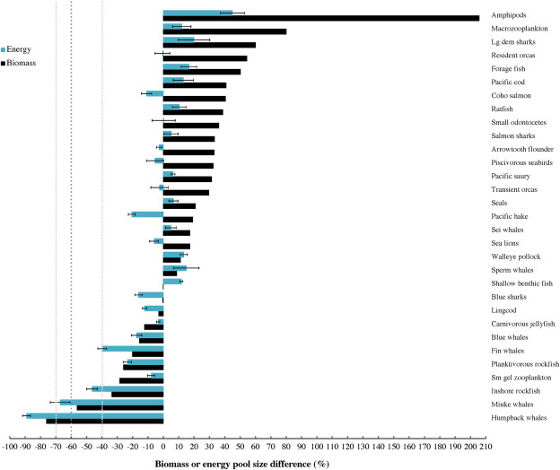

1. [Download: Download high-res image (442KB)](https://ars-els-cdn-com.reed.idm.oclc.org/content/image/1-s2.0-S0967064521000771-gr4_lrg.jpg)
2. [Download: Download full-size image](https://ars-els-cdn-com.reed.idm.oclc.org/content/image/1-s2.0-S0967064521000771-gr4.jpg)

Fig. 4. Results of the herring collapse simulation in the recent mass- and energy-balanced models, expressed as percentage differences (≥10%) between final functional group biomasses (black) and [energy densities](https://www-sciencedirect-com.reed.idm.oclc.org/topics/earth-and-planetary-sciences/flux-density) (blue-green) in the herring collapse (i.e. ≥ 95% reduction) versus baseline (herring *F* = 0) scenarios. Error bars indicate 95% confidence intervals around mean changes across energy-balanced models. Lg dem sharks = large demersal sharks and sm gel zooplankton = small gelatinous zooplankton. The dotted lines mark the thresholds employed to assess key forage fish status. (For interpretation of the references to colour in this figure legend, the reader is referred to the Web version of this article.)

Some functional group responses differed in sign among scenarios or models. In the historical mass-balanced model, nearly all functional groups responding with declines ≥10% to herring collapse (scenario #3) responded with biomass increases to herring depletion (scenario #2), except for carnivorous jellyfish and small [gelatinous zooplankton](https://www-sciencedirect-com.reed.idm.oclc.org/topics/agricultural-and-biological-sciences/gelatinous-zooplankton) (Fig. 2). In the recent mass-balanced model, such a change in response sign from negative to positive was only found in shallowwater benthic fish (Fig. 3, Fig. 4). Consistently positive responses (≥10%) to herring depletion and collapse occurred across all models for macrozooplankton, [amphipods](https://www-sciencedirect-com.reed.idm.oclc.org/topics/agricultural-and-biological-sciences/amphipoda), forage fish, [walleye pollock](https://www-sciencedirect-com.reed.idm.oclc.org/topics/agricultural-and-biological-sciences/alaska-pollock) *[Gadus](https://www-sciencedirect-com.reed.idm.oclc.org/topics/agricultural-and-biological-sciences/gadus)* *chalcogrammus*, Pacific cod *G. macrocephalus*, and seals (Fig. 2, Fig. 3, Fig. 4).

In addition, several herring predators (sea lions, piscivorous seabirds, [coho salmon](https://www-sciencedirect-com.reed.idm.oclc.org/topics/agricultural-and-biological-sciences/oncorhynchus-kisutch) *O. kisutch*, Pacific hake *[Merluccius productus](https://www-sciencedirect-com.reed.idm.oclc.org/topics/agricultural-and-biological-sciences/merluccius-productus)*, and [arrowtooth flounder](https://www-sciencedirect-com.reed.idm.oclc.org/topics/agricultural-and-biological-sciences/arrowtooth-flounder) *Atheresthes stomias*) responded positively (by ≥ 10%) to herring depletion (scenario #2, Fig. 3) and collapse (scenario #2, Fig. 4) in the recent mass-balanced model but reacted negatively across all energy-balanced models. Furthermore, for three marine mammal functional groups reliant on herring directly (small odontocetes) or indirectly (resident and transient orcas *[Orcinus orca](https://www-sciencedirect-com.reed.idm.oclc.org/topics/agricultural-and-biological-sciences/orcinus-orca)*), responses to both scenarios were positive (≥10%) in the recent mass-balanced model but negative when averaged across energy-balanced models, although 95% confidence intervals around the mean responses included zero. Finally, in six herring predator groups (humpback, fin, and minke whales, inshore rockfish, lingcod, and blue sharks *Prionace glauca*), negative responses to both scenarios (≥10%) intensified in energy-balanced models relative to the recent mass-balanced model, while positive responses strengthened in only three functional groups (sperm whales, walleye pollock, and shallowwater benthic fish).

## 4. Discussion

### 4.1. Static ecosystem analyses

The *SURF* index provided only limited support for the status of herring as a key forage fish in the southeastern Gulf of Alaska. Neither the historical nor recent mass-balanced model yielded *SURF* values for herring indicating key status (Plagányi and Essington 2014). This result agrees with those obtained by the original *SURF* analysis from Ecopath models for Hecate Strait, west-central Gulf of Alaska, Aleutian Islands, and Puget Sound (Plagányi and Essington 2014) and only conflicts with its finding for Prince William Sound. It also accords with the finding yielded by an earlier version of the recent mass-balanced model (Lam et al., 2019). However, one energy-balanced model (#3) produced a *SURF* value suggesting key forage fish status for herring. This result can be explained by the extremely high energy content values for adult herring (9–10 kJ⋅g<sup>−1</sup>) compared to those for the forage fish group (4 kJ⋅g<sup>−1</sup>) in model #3. Nevertheless, five of seven energy-balanced models yielded *SURF* values for herring less than half an order of magnitude below the threshold. This suggests that herring is more likely to qualify as a key forage fish when the high energy content of adult herring relative to other Northeast Pacific prey species (Perez 1994; Anthony et al., 2000; Vollenweider et al., 2011) is considered. This finding agrees with that of a recent study (Surma et al., 2018a) regarding the enhanced importance of herring to predators due to its elevated energy content. The key status of the aggregated forage fish group across all models can be explained by its high biomass, and in the absence of species-specific biomass estimates it is uninformative regarding the key status (or lack thereof) of its constituent species.

### 4.2. Dynamic ecosystem simulations

These findings agree with those of an early ecosystem simulation analysis (Mackinson et al., 1997) regarding the consequences of forage fish depletion, i.e. direct negative effects on some predators, increased zooplankton and planktivorous competitor biomass, and resulting indirect positive impacts on other predators. They also accord with the adverse impacts of forage fish depletion on predators frequently detected in two global studies (Smith et al., 2011, Pikitch et al., 2012a,b). More specifically, negative impacts of herring depletion on humpback and minke whales, as well as planktivorous rockfish (*[Sebastes](https://www-sciencedirect-com.reed.idm.oclc.org/topics/agricultural-and-biological-sciences/sebastes)* spp.), were likewise observed in an EwE model of the California Current ecosystem adjoining the Gulf of Alaska to the south (Koehn et al., 2017). Ecosystem models of the southeastern Gulf of Alaska and California Current also agree in emphasizing the roles of food web complexity and forage fish guild redundancy in modulating the impacts of herring depletion on predators (Kaplan et al. 2013, 2017; Koehn et al. 2016, 2017). In the California Current, simulated forage fish depletion in both EwE and Atlantis positively affected some zooplankton and planktivorous fish through release from predation and competition, respectively (Kaplan et al. 2013, 2017). These releases resulted from generalist feeding by most predators and functional redundancy among forage fish (Koehn et al., 2016; Kaplan et al., 2017). However, it should be noted here that herring accounts for a much lower proportion of total forage fish biomass in the California Current (Koehn et al., 2016) than in the southeastern Gulf of Alaska (Surma et al., 2019). Nevertheless, an ecosystem simulation study of the importance of Atlantic menhaden (*[Brevoortia tyrannus](https://www-sciencedirect-com.reed.idm.oclc.org/topics/agricultural-and-biological-sciences/brevoortia-tyrannus)*), a key forage fish in [Chesapeake Bay](https://www-sciencedirect-com.reed.idm.oclc.org/topics/earth-and-planetary-sciences/chesapeake-bay) (Plagányi and Essington 2014), to predators in the Northwest Atlantic off the east coast of the United States (Buchheister et al., 2017) yielded similar findings.

While herring did not emerge as a key forage fish in the mass-balanced model simulations, it was classified as such based on simulation results from most energy-balanced models (criterion A1). These results indicate that herring depletion could affect numerous predators more adversely than suggested by the corresponding mass-balanced model (Fig. 3). These predators include endothermic piscivorous seabirds and marine mammals (humpback, minke, and fin whales, sea lions, and small odontocetes) as well as ectothermic fish (inshore rockfish, lingcod, blue sharks, hake, [coho salmon](https://www-sciencedirect-com.reed.idm.oclc.org/topics/agricultural-and-biological-sciences/oncorhynchus-kisutch), and arrowtooth flounder). These results agree with recent findings regarding the high metabolic demands of small odontocetes and their resulting preference for energy-rich forage fish (Spitz et al. 2010a, 2012, 2018; Marçalo et al., 2018; Rojano-Donãte et al., 2018, Tsagarakis et al., 2021). They also accord with conclusions on analogous energetic drivers of seabird (Litzow et al., 2004) and sea lion (Trites and Donnelly, 2003) foraging ecology, and the consequent association between energy-rich forage fish availability and breeding success in numerous seabirds (Litzow et al., 2004; Anchundia et al., 2014; Divoky et al., 2015) and sea lions (Trites and Donnelly 2003; McClatchie et al., 2016a; Banuet-Martínez et al., 2017), as well as Brandt's cormorant (*[Phalacrocorax](https://www-sciencedirect-com.reed.idm.oclc.org/topics/agricultural-and-biological-sciences/phalacrocorax)* *penicillatus*) colony size in the central California Current (Ainley et al., 2018). Finally, these findings support the hypothesis that the high energy content of forage fish (Engelhard et al., 2014) such as Pacific herring (Surma et al., 2018a) could intensify the impacts of their depletion on predators. However, this hypothesis is somewhat complicated by observations that although many active, endothermic predators (e.g. small penguins) selectively hunt energy-rich prey, they also consume low-energy species (e.g. scyphozoan jellyfish and ctenophores) even in the presence of preferred, energy-rich resources (Thiebot et al., 2017; Hays et al., 2018). In southeast Alaska, low-energy prey (e.g. walleye pollock) can contribute substantially to [Steller sea lion](https://www-sciencedirect-com.reed.idm.oclc.org/topics/agricultural-and-biological-sciences/steller-sea-lion) diet if sufficient high-energy prey (e.g. herring) are also ingested (Sigler et al., 2009). In the Northeast Pacific, humpback whale net energy gain from consumption of relatively energy-poor but slow-swimming krill can exceed that from energy-rich but faster-moving herring or [northern anchovy](https://www-sciencedirect-com.reed.idm.oclc.org/topics/agricultural-and-biological-sciences/californian-anchovy) (*Engraulis mordax*) if krill aggregations are dense enough (Chenoweth et al., 2021, Savoca et al., 2021).

Nevertheless, it is noteworthy that the southeastern Gulf of Alaska food web responded strongly to simulated herring collapse (scenario #3), with herring meeting criterion A1 for key forage fish status in this scenario across all ecosystem models (Fig. 2, Fig. 4). The frequency and severity of herring stock collapses worldwide (Trochta et al., 2020) highlight the importance of these results. Furthermore, recent studies cast doubt on the ability of functional redundancy in forage fish guilds, and competition among their members, to buffer the bottom-up impacts of individual forage fish declines on higher [trophic levels](https://www-sciencedirect-com.reed.idm.oclc.org/topics/earth-and-planetary-sciences/trophic-level). Firstly, the intense [marine heatwave](https://www-sciencedirect-com.reed.idm.oclc.org/topics/earth-and-planetary-sciences/marine-heatwave) of 2014–2016 in the Gulf of Alaska triggered rapid and synchronous declines in Pacific herring and capelin biomass, as well as Pacific sandlance energy content, through acute bottom-up impacts on prey quality, with severe and widespread repercussions for seabirds, marine mammals, and large fish deprived of sufficient energy-rich prey (Arimitsu et al., 2021; Suryan et al., 2021). Secondly, a global analysis determined that multidecadal fluctuations in sardine and anchovy biomasses, long considered asynchronous, exhibit more complex dynamics with the potential to disrupt their hypothesized buffering effect on predator responses to forage fish declines (Siple et al., 2020).

Thus, the findings of the present study and other recent analyses highlight the need for a cautious approach to the supposed buffering of adverse impacts on predators by functional redundancy in forage fish guilds (Walters et al., 2016). They also support calls for precautionary, ecosystem-based fisheries management for forage fish in general (Smith et al., 2011; Pikitch et al., 2012a,b, 2018) and Pacific herring in the southeastern Gulf of Alaska in particular (Surma et al., 2018a,b; Surma et al., 2021; Lam et al., 2019). In addition, these findings disagree with those of several recent studies questioning the importance of forage fish to predators (Hilborn et al., 2017; Free et al., 2021).

The ecosystem simulation results of the present study are burdened with several caveats and limitations. Firstly, any errors in EwE parameters derived from inputs or fits to time series (Surma et al., 2019) may affect simulation outputs through multiple pathways, including predator functional responses. Secondly, the common practice of aggregating species (e.g. forage fish or seabirds) into functional groups in ecosystem models may mask negative effects of depleting specific forage fish (e.g. Pacific sardine *[Sardinops sagax](https://www-sciencedirect-com.reed.idm.oclc.org/topics/agricultural-and-biological-sciences/sardinops-sagax)*) on specialist predators (e.g. [brown pelicans](https://www-sciencedirect-com.reed.idm.oclc.org/topics/agricultural-and-biological-sciences/brown-pelican) *Pelecanus occidentalis*; Punt et al., 2016; Kaplan et al., 2019). Thirdly, the lack of a high-resolution representation of spatiotemporal overlap between predators and prey in an ecosystem model may obscure the importance of fine-scale variability in forage fish biomass to central place foragers such as pinnipeds and seabirds (Koehn et al., 2017; Sydeman et al., 2017a). For example, in southeast Alaska, persistent herring aggregations provide crucial feeding areas for Steller sea lions (Gende and Sigler 2006). Fourthly, the absence of an explicit age-structured representation of [predatory fish](https://www-sciencedirect-com.reed.idm.oclc.org/topics/agricultural-and-biological-sciences/predatory-fish) biomass (except for Pacific halibut *[Hippoglossus stenolepis](https://www-sciencedirect-com.reed.idm.oclc.org/topics/agricultural-and-biological-sciences/hippoglossus-stenolepis)*) may lead ecosystem simulations to overestimate the strength of trophic responses to forage fish depletion (Forrest et al., 2015; Walters et al., 2016; Kaplan et al., 2017). Fifthly, the lack of a model representation of seasonality in predator diets, e.g. due to fluctuating herring availability (Willson and Womble 2006; Womble and Sigler 2006) and energy content (Anthony et al., 2000; Vollenweider et al., 2011), may affect ecosystem simulation results. Finally, the use of a scenario (#1) with fisheries closed for one species (i.e. herring) but open for all others as a “baseline” may yield a release of herring biomass not reflecting a true ecosystem baseline, in which unfished predators could absorb much of the likewise unfished herring biomass through top-down control.

In addition, the ecological importance of herring may have decreased over time due to depletion by [commercial fisheries](https://www-sciencedirect-com.reed.idm.oclc.org/topics/earth-and-planetary-sciences/commercial-fishery). High herring biomass in the southeastern Gulf of Alaska *circa* 1950, as represented in the historical mass-balanced model (Surma et al., 2019), would likely have ranked herring as a key forage fish once its high energy content was incorporated into such a model. Furthermore, while estimated annual biomasses (DFO 2015) and carrying capacities (Perry and Schweigert 2008) based on [stock assessments](https://www-sciencedirect-com.reed.idm.oclc.org/topics/earth-and-planetary-sciences/stock-assessment) extend no further than 1951, zooarchaeological data indicate that herring abundance in the Northeast Pacific declined steeply since the onset of commercial fisheries in the 19th century (McKechnie et al., 2014), suggesting that its ecological importance may have also decreased. However, eulachon, a forage fish with an energy content exceeding even that of herring (Perez 1994; Anthony et al., 2000; Vollenweider et al., 2011), is also more heavily depleted, raising the intriguing question of the relative significance of these two species in Northeast Pacific ecosystems prior to commercial fishing (Osgood et al., 2016).

When analyzed across all models, depletion simulation results support the hypothesis that a mosaic of top-down and bottom-up control characterizes herring [trophic interactions](https://www-sciencedirect-com.reed.idm.oclc.org/topics/earth-and-planetary-sciences/trophic-interaction) in the southeastern Gulf of Alaska (Surma et al., 2019). Mass- and energy-balanced models indicate that herring exerts strong bottom-up effects on humpback and minke whales as well as inshore rockfish. Furthermore, energy-balanced models suggest that herring biomass may also have notable bottom-up impacts on blue sharks, lingcod, Pacific hake, coho salmon, and perhaps piscivorous seabirds, sea lions, and small odontocetes. Bottom-up effects of herring availability on many predators agree with the findings of previous studies on the trophic roles of forage fish (Smith et al., 2011, Pikitch et al., 2012a,b; Engelhard et al., 2014). The substantial proportion of fish among predators apparently supported by herring accords with the results of these analyses, but not the conclusions of others suggesting that mammals and particularly seabirds are most heavily dependent on forage fish (Hannesson 2013; Hilborn et al., 2017). Simulation results from all models also indicate top-down control by herring over two omnivorous zooplankton groups (macrozooplankton and amphipods). These findings agree with observed top-down effects of other forage fish on zooplankton (Cury et al., 2000; Engelhard et al., 2014).

At first glance, this pattern of bottom-up impacts of herring on predators and top-down effects on prey is reminiscent of the “wasp-waist” trophodynamics proposed for other forage fish (Cury et al., 2000). However, previous studies (Heintz et al., 2010; Surma and Pitcher 2015; Boswell et al., 2015, Moran et al., 2018; Straley et al., 2018) indicate that recovering humpback whales could exert top-down impacts on herring in the Gulf of Alaska. Furthermore, network analysis (mixed trophic impacts) and ecosystem hindcasts conducted using the historical mass-balanced model (Surma et al., 2019) suggest that herring biomass is also subject to bottom-up effects of variable primary and secondary productivity (phytoplankton and copepods, respectively). This finding, together with the competition among planktivorous fish detected in the present study, agrees with bottom-up control of the productivity of commercial fish in general (Ware and Thomson 2005) and herring in particular (Perry and Schweigert 2008) in the Northeast Pacific, as well as forage fish productivity in the North Sea (Engelhard et al., 2014). Thus, Pacific herring trophodynamics appears to be substantially more intricate than the “wasp-waist” hypothesis would suggest. In addition, this hypothesis has been more generally criticized as an oversimplification of forage fish trophodynamics in complex food webs (Madigan et al., 2012; Bundy and Guénette 2014).

## 5. Conclusions

The analyses presented in this study lead to several conclusions. Firstly, Pacific herring may function as a key forage fish in the southeastern Gulf of Alaska when its energy content is high relative to those of other forage fish. Secondly, herring biomass supports numerous predators, including piscivorous fish, marine mammals, and seabirds. Thirdly, bottom-up impacts of herring availability on these predators may be partly damped by functional redundancy within the forage fish guild. Fourthly, however, these bottom-up effects of herring on many predators are likely intensified by the high energy content of herring relative to other prey in the Gulf of Alaska. Fifthly, herring can exert top-down impacts on omnivorous zooplankton. Finally, similarities between herring trophodynamics and the “wasp-waist” hypothesis appear superficial.

The findings of this study indicate that the demand of predators for herring should be included in a comprehensive perspective on its ecology. These results support the need for precautionary, ecosystem-based fisheries management strategies in Northeast Pacific herring fisheries (Surma et al., 2018b, Surma et al., 2021). Furthermore, given the demonstrated capacity of climate-driven seasonal and interannual shifts in energy-rich zooplankton abundance to reduce the biomass or energy content of [pelagic fish](https://www-sciencedirect-com.reed.idm.oclc.org/topics/agricultural-and-biological-sciences/pelagic-fish) in the Gulf of Alaska (Arimitsu et al., 2021; Suryan et al., 2021) and throughout the Northeast Pacific (Mackas et al., 2007; Hunt et al., 2011; Heintz et al., 2013; Siddon et al., 2013; McClatchie et al., 2016b), the calls for ecosystem-based fisheries management for such species gain strength and urgency from increasingly frequent [marine heatwaves](https://www-sciencedirect-com.reed.idm.oclc.org/topics/earth-and-planetary-sciences/marine-heatwave) and global [climate change](https://www-sciencedirect-com.reed.idm.oclc.org/topics/agricultural-and-biological-sciences/climate-change) (Di Lorenzo and Mantua 2016; Alexander et al., 2018; Cheung and Frölicher 2020).

## Funding

This work was supported by the Natural Sciences and Engineering Research Council of Canada [grant numbers 6564 and 447247].

## Declaration of competing interest

The authors declare that they have no known competing financial interests or personal relationships that could have appeared to influence the work reported in this paper.

## Acknowledgements

The corresponding author thanks his former doctoral supervisory committee member Dr. Villy Christensen (University of British Columbia) for greatly assisting and improving his research with suggestions and feedback. Other colleagues meriting sincere thanks for their contributions to the ecosystem model design process, as well as general support and encouragement of the authors' work, include Dr. Cameron Ainsworth (University of South Florida), Dr. Rajeev Kumar (Memorial University of Newfoundland), Dr. Divya Varkey (Fisheries and Oceans Canada), and Dr. Mimi E. Lam (University of Bergen). The authors also wish to thank Jeroen Steenbeek and Joe Buszowski (EwE Research and Development Consortium) for their repeated technical assistance, including preparation of custom EwE functionality.

## Appendices A and B. Supplementary data

[What’s this?](https://service.elsevier.com/app/answers/detail/a_id/19286/supporthub/sciencedirect/)

The following are the Supplementary data to this article:[Download: Download spreadsheet (91KB)](https://ars-els-cdn-com.reed.idm.oclc.org/content/image/1-s2.0-S0967064521000771-mmc1.xlsx)

Supplementary file S1.

[Download: Download Word document (25KB)](https://ars-els-cdn-com.reed.idm.oclc.org/content/image/1-s2.0-S0967064521000771-mmc2.docx)

Appendix A.

[Download: Download Word document (135KB)](https://ars-els-cdn-com.reed.idm.oclc.org/content/image/1-s2.0-S0967064521000771-mmc3.docx)

Appendix B.

## References

1. Ainley et al., 2018

   D.G. Ainley, J.A. Santora, P.J. Capitolo, J.C. Field, J.N. Beck, *et al.*

   Ecosystem-based management affecting Brandt's Cormorant resources and populations in the central California Current region

   Biol. Conserv., 217 (2018), pp. 407-418, 10.1016/j.biocon.2017.11.021

   [View PDF](https://www-sciencedirect-com.reed.idm.oclc.org/science/article/pii/S0006320717310601/pdfft?md5=ad1aaa6854b81654e6cdc85c3225842a&pid=1-s2.0-S0006320717310601-main.pdf)[View article](https://www-sciencedirect-com.reed.idm.oclc.org/science/article/pii/S0006320717310601)[View in Scopus](https://www.scopus.com/inward/record.url?eid=2-s2.0-85035309519&partnerID=10&rel=R3.0.0)Google Scholar
2. Ainsworth et al., 2008

   C.H. Ainsworth, T.J. Pitcher, J.J. Heymans, M. Vasconcellos

   Reconstructing historical marine ecosystems using food web models: northern British Columbia from Pre-European contact to present

   Ecol. Model., 216 (2008), pp. 354-368, 10.1016/j.ecolmodel.2008.05.005

   [View PDF](https://www-sciencedirect-com.reed.idm.oclc.org/science/article/pii/S0304380008002299/pdfft?md5=0758e31ad3dd1d1337b9b1403f9889a0&pid=1-s2.0-S0304380008002299-main.pdf)[View article](https://www-sciencedirect-com.reed.idm.oclc.org/science/article/pii/S0304380008002299)[View in Scopus](https://www.scopus.com/inward/record.url?eid=2-s2.0-47249153105&partnerID=10&rel=R3.0.0)Google Scholar
3. Alexander et al., 2018

   M.A. Alexander, J.D. Scott, K.D. Friedland, K.E. Mills, J.A. Nye, *et al.*

   Projected sea surface temperatures over the 21st century: changes in the mean, variability and extremes for large marine ecosystem regions of Northern Oceans

   Elem. Sci. Anth., 6 (2018), p. 9, 10.1525/elementa.191

   [View at publisher](https://doi.org/10.1097/nan.0000000000000266)Google Scholar
4. Anchundia et al., 2014

   D. Anchundia, K.P. Huyvaert, D.J. Anderson

   Chronic lack of breeding by Galápagos Blue-footed Boobies and associated population decline

   Avian Conserv. Ecol., 9 (1) (2014), p. 6, 10.5751/ACE-00650-090106

   [View at publisher](https://doi.org/10.5751/ACE-00650-090106)[View in Scopus](https://www.scopus.com/inward/record.url?eid=2-s2.0-84903762625&partnerID=10&rel=R3.0.0)Google Scholar
5. Anthony et al., 2000

   J.A. Anthony, D.D. Roby, K.R. Turco

   Lipid content and energy density of forage fishes from the northern Gulf of Alaska

   J. Exp. Mar. Biol. Ecol., 248 (2000), pp. 53-78, 10.1016/S0022-0981(00)00159-3

   [View PDF](https://www-sciencedirect-com.reed.idm.oclc.org/science/article/pii/S0022098100001593/pdfft?md5=aa04c271e206c0a4bd21c29020f58c79&pid=1-s2.0-S0022098100001593-main.pdf)[View article](https://www-sciencedirect-com.reed.idm.oclc.org/science/article/pii/S0022098100001593)[View in Scopus](https://www.scopus.com/inward/record.url?eid=2-s2.0-0034682224&partnerID=10&rel=R3.0.0)Google Scholar
6. Arimitsu et al., 2021

   M.L. Arimitsu, J.F. Piatt, S. Hatch, R.M. Suryan, *et al.*

   Heatwave-induced synchrony within forage fish portfolio disrupts energy flow to top pelagic predators

   Global Change Biol., 27 (9) (2021), pp. 1859-1878, 10.1111/gcb.15556

   [View at publisher](https://ct.prod.getft.io/c2NpZW5jZWRpcmVjdF9jb250ZW50aG9zdGluZyx3aWxleSxodHRwczovL29ubGluZWxpYnJhcnkud2lsZXkuY29tL2RvaS9lcGRmLzEwLjExMTEvZ2NiLjE1NTU2P3NyYz1nZXRmdHI.I6kfxLWYnQDwHxy1Xj4JUNAtLXrd6KfdPTQQn__LHH4)

   [View in Scopus](https://www.scopus.com/inward/record.url?eid=2-s2.0-85102082927&partnerID=10&rel=R3.0.0)Google Scholar
7. Banuet-Martínez et al., 2017

   M. Banuet-Martínez, W. Espinosa-de Aquino, F.R. Elorriaga-Verplancken, A. Flores- Morán, O.P. García, *et al.*

   Climatic anomaly affects the immune competence of California sea lions

   PLoS One, 12 (6) (2017), Article e0179359, 10.1371/journal.pone.0179359

   [View at publisher](https://doi.org/10.1371/journal.pone.0179359)[View in Scopus](https://www.scopus.com/inward/record.url?eid=2-s2.0-85021677520&partnerID=10&rel=R3.0.0)Google Scholar
8. Bishop et al., 2015

   M.A. Bishop, J.T. Watson, K. Kuletz, T. Morgan

   Pacific herring (*Clupea pallasii*) consumption by marine birds during winter in Prince William Sound, Alaska

   Fish. Oceanogr., 24 (1) (2015), pp. 1-13, 10.1111/fog.12073

   View at publisher

   [View in Scopus](https://www.scopus.com/inward/record.url?eid=2-s2.0-84922770999&partnerID=10&rel=R3.0.0)Google Scholar
9. Boswell et al., 2015

   K.M. Boswell, G. Rieucau, J.J. Vollenweider, J.R. Moran, R.A. Heintz, *et al.*

   Are spatial and temporal patterns in Lynn Canal overwintering Pacific herring related to top predator activity?

   Can. J. Fish. Aquat. Sci., 73 (2015), pp. 1307-1318, 10.1139/cjfas-2015-0192

   [View at publisher](https://doi.org/10.1139/cjfas-2015-0192)Google Scholar
10. Brodeur et al., 2014

    R.D. Brodeur, J.C. Buchanan, R.L. Emmett

    Pelagic and demersal fish predators on juvenile and adult forage fishes in the northern California Current: spatial and temporal variations

    CALCOFI (Calif. Coop. Ocean. Fish. Investig.) Rep., 55 (2014), pp. 96-117

    Google Scholar
11. Buchheister et al., 2017

    A. Buchheister, T.J. Miller, E.D. Houde

    Evaluating ecosystem-based reference points for atlantic menhaden

    Mar. Coast. Fish Dynam. Manag. Ecosys. Sci., 9 (2017), pp. 457-478, 10.1080/19425120.2017.1360420

    View at publisher

    [View in Scopus](https://www.scopus.com/inward/record.url?eid=2-s2.0-85051784588&partnerID=10&rel=R3.0.0)Google Scholar
12. Bundy and Guénette, 2014

    A. Bundy, S. Guénette

    Loosening the corset: how real are wasp-waist ecosystems?

    J. Steenbeek, C. Piroddi, M. Coll, J.J. Heymans, S. Villasante, *et al.* (Eds.), Ecopath 30 Years Conference Proceedings: Extended Abstracts. *UBC Fish*. Centre Res. Rep, vol. 22 (2014), p. 33

    3

    [Google Scholar](https://scholar.google.com/scholar_lookup?title=Loosening%20the%20corset%3A%20how%20real%20are%20wasp-waist%20ecosystems&publication_year=2014&author=A.%20Bundy&author=S.%20Gu%C3%A9nette)
13. Casini et al., 2006

    M. Casini, M. Cardinale, J. Hjelm

    Inter-annual variation in herring, *Clupea harengus*, and sprat, *Sprattus*, condition in the central Baltic Sea: what gives the tune?

    Oikos, 112 (2006), pp. 638-650, 10.1111/j.0030-1299.2006.13860.x

    View at publisher

    [View in Scopus](https://www.scopus.com/inward/record.url?eid=2-s2.0-33645120410&partnerID=10&rel=R3.0.0)Google Scholar
14. Chamberlin et al., 2021

    J. Chamberlin, E. Petrou, W. Duguid, R. Barsh, F. Juanes, *et al.*

    Phenological diversity of a prey species supports life-stage specific foraging opportunity for a mobile consumer

    ICES J. Mar. Sci., 78 (9) (2021), pp. 3089-3100, 10.1093/icesjms/fsab176

    View at publisher

    [View in Scopus](https://www.scopus.com/inward/record.url?eid=2-s2.0-85121139115&partnerID=10&rel=R3.0.0)Google Scholar
15. Chenoweth et al., 2021

    E.M. Chenoweth, K.M. Boswell, A.S. Friedlaender, M.V. McPhee, J.A. Burrows, *et al.*

    Confronting assumptions about prey selection by lunge-feeding whales using a process-based model

    Funct. Ecol., 35 (8) (2021), pp. 1722-1734, 10.1111/1365-2435.13852

    [View at publisher](https://ct.prod.getft.io/c2NpZW5jZWRpcmVjdF9jb250ZW50aG9zdGluZyx3aWxleSxodHRwczovL29ubGluZWxpYnJhcnkud2lsZXkuY29tL2RvaS9wZGYvMTAuMTExMS8xMzY1LTI0MzUuMTM4NTI.Gc41o4NOWltdpecpm90UgEuMjFz-Ig04y9_mTK-VRqY)

    [View in Scopus](https://www.scopus.com/inward/record.url?eid=2-s2.0-85109171292&partnerID=10&rel=R3.0.0)Google Scholar
16. Cheung and Frölicher, 2020

    W.W.L. Cheung, T.L. Frölicher

    Marine heatwaves exacerbate climate change impacts for fisheries in the northeast Pacific

    Nature Sci. Rep., 10 (2020), p. 6678, 10.1038/s41598-020-63650-z

    View at publisher

    [View in Scopus](https://www.scopus.com/inward/record.url?eid=2-s2.0-85083784043&partnerID=10&rel=R3.0.0)Google Scholar
17. Christensen and Walters, 2004

    V. Christensen, C.J. Walters

    Ecopath with Ecosim: methods, capabilities and limitations

    Ecol. Model., 172 (2004), pp. 109-139, 10.1016/j.ecolmodel.2003.09.003

    [View PDF](https://www-sciencedirect-com.reed.idm.oclc.org/science/article/pii/S030438000300365X/pdfft?md5=a11722a28657f340549808ace84c8473&pid=1-s2.0-S030438000300365X-main.pdf)[View article](https://www-sciencedirect-com.reed.idm.oclc.org/science/article/pii/S030438000300365X)[View in Scopus](https://www.scopus.com/inward/record.url?eid=2-s2.0-1242321252&partnerID=10&rel=R3.0.0)[Google Scholar](https://scholar.google.com/scholar_lookup?title=Ecopath%20with%20Ecosim%3A%20methods%2C%20capabilities%20and%20limitations&publication_year=2004&author=V.%20Christensen&author=C.J.%20Walters)
18. Cleary et al., 2010

    J.S. Cleary, S.P. Cox, J.F. Schweigert

    Performance evaluation of harvest control rules for Pacific herring management in British Columbia, Canada

    ICES J. Mar. Sci., 67 (2010), pp. 2005-2011, 10.1093/icesjms/fsq129

    View at publisher

    [View in Scopus](https://www.scopus.com/inward/record.url?eid=2-s2.0-78649379952&partnerID=10&rel=R3.0.0)Google Scholar
19. Coll et al., 2015

    M. Coll, E. Akoglu, F. Arreguín-Sánchez, E.A. Fulton, D. Gascuel, *et al.*